# Plaques Project

Lada Maksimova

04 04 2020

## Introduction

The following research aims to explore plaquing patterns in SPb and analyze commemorative strategies of the city authorities.

### Step 1. Gathering, cleaning and ingesting the data

## Packadges loading

```r
packages <- c("data.table", "stringi", "stringr", "rvest", "httr", "xml2", "readr", "tidyverse", "ggmap", "lubridate", "anytime", "ggplot2" )
if (length(setdiff(packages, rownames(installed.packages()))) > 0) {

  install.packages(setdiff(packages, rownames(installed.packages())))
}

capture.output(lapply(packages, library, character.only = T), file='NULL')
```

```
## Google's Terms of Service: https://cloud.google.com/maps-platform/terms/.
```

```r
setwd("C:/Users/Xiaomi/Documents/plaques_progect")
```

## Parsing the data

The most extensive but not nearly exhaustive repository of information on memorial plaques of Saint Petersburg can be found in “Encyclopedia of Saint Petersburg” website with 887 pages of plaques devoted to individuals. If we refer to the website , we’ll se that there’s 30 pages that we will nedd to go through. To do so we will need to perform this chunk of code:

```r
plaques_web <- xml2::read_html('http://encspb.ru/object/2805516545/D_1803401815/')

plaque_object_inventory <- c()

for( i in 1:30 ) {
    url_to_query <- paste0("http://encspb.ru/object/2805516545/D_1803401815/", i)
    page_content <- httr::GET(url_to_query)
    page_dom <- xml2::read_html(page_content$content)
    plaque_objects <- xml_attr(xml2::xml_find_all(page_dom, "//a[@class='wp_td_link link']"), "href")
    plaque_object_inventory <- c(plaque_object_inventory, plaque_objects)
}
```

Next step is to get all the files with the individual plaque pages. It will make the following extracton of the information faster. I’m also storing the unique IDs of every page, for thevariable that will come in handy in the future.

```r
html_list <- c()
ids <- c()

for(obj in plaque_object_inventory) {

    url_to_query <- paste0("http://encspb.ru", obj)

    # Unique ID
    objid <- gsub('[^0-9.-]','', obj)
    ids <- c(ids, objid)

    curr_html_name <- paste0("plaques_file", objid, ".html")
    html_list <- c(html_list, curr_html_name)

    # httr::GET(url_to_query,
    #           write_disk(curr_html_name))
}
```

And further on, the following chunk of code will go through the files and extract the information on the name of the ‘plaqued’ person(title), text inscripred on plaque, the year of plaque installation and address. As the website is fairly old and rather disorganized, I will copy the whole plaque related text into one extra variable called “description” for backup. If extracting information with following-sibling method turns out to be inefficient, I will be able to simply split “description” column into three.

```r
plaque_address <- c()
plaque_title <- c()
plaque_content <-  c()
plaque_year <- c()

for (n in html_list) {

  page_content <- read_file(n)
  curr_page <- xml2::read_html(page_content)

#column with name(title)
  page_title <- html_nodes(curr_page, "h3")
  pl_title <- html_text(page_title)

  if (length(pl_title) == 0) {
    pl_title <- NA
  }

  plaque_title <- c(plaque_title, pl_title)

#column with year, architect, material
  pl_year <- xml2::xml_find_all(curr_page, "//div[@class='inner_object']/text()[preceding-sibling::br[3]][1]")
  pl_year <- xml_text(pl_year)

  if (length(pl_year) == 0) {
    pl_year <- NA
  }
  plaque_year <-  c(plaque_year, pl_year)


#column with description
  page_desc <- html_nodes(curr_page, ".inner_object")
  pl_description <- html_text(page_desc)
  pl_content <- gsub('\n', '', pl_description)
  pl_content <- gsub( '\\s+', ' ', pl_content)

  if (length(pl_content) == 0) {
    pl_content <- NA
  }

  plaque_content <- append(plaque_content, pl_content)

#column with address
  pl_address <- xml2::xml_find_all(curr_page, "//div[@class='grName']/following-sibling::a[3]")
  pl_address <- xml_text(pl_address[1])

  if (length(pl_address) == 0) {
    pl_address <- NA
  }

  plaque_address <- c(plaque_address, pl_address[1])

}
```

Finally, the dataset can be created.

```r
df_plaques <-  data.frame(
  ID = ids,
  TITLE = plaque_title,
  DESCRIPTION = plaque_content,
  ARCHITECT = plaque_year,
  ADDRESS = plaque_address)
```

## Cleaning the dataset

Let’s take a look at the resulting dataset

```r
knitr::kable(df_plaques[1:5,1:5], format="markdown")
```

| ID | TITLE | DESCRIPTION | ARCHITECT | ADDRESS |
| --- | --- | --- | --- | --- |
| 2805549264 | Абрамову Ф.А., мемориальная доска | Абрамову Ф.А., мемориальная доска Рубрикатор / Мемориальные доски/Именные мемориальные доски «В этом доме в 1982–1983 годах жил и работал писатель Федор Александрович Абрамов»1992. Арх. Милорадович Т.… | 1992. Арх. Милорадович Т. Н. Гранит. | Мичуринская ул./Санкт-Петербург, д. 1 |
| 2805524742 | Авелану Ф. К. [и другим адмиралам, воспитывавшимся в Александровском кадетском корпусе], мемориальная доска | Авелану Ф. К. [и другим адмиралам, воспитывавшимся в Александровском кадетском корпусе], мемориальная доска Рубрикатор / Мемориальные доски/Именные мемориальные доски «Здесь, в морской роте Александро… | 1997. Арх. Абрамов Е. П., скульптор Гольбрайх И. А. Гранит. | Гольбрайх И. А. |
| 2805531039 | Агееву Н. В., мемориальная доска | Агееву Н. В., мемориальная доска Рубрикатор / Мемориальные доски/Именные мемориальные доски «В этом здании в период с 1925 по 1936 год работал академик Николай Владимирович Агеев»1989. Арх. Степанов Г… | Политехническая ул., 29, Технический университет, химический корпус | Политехническая ул./Санкт-Петербург, д. 29 |
| 2805526222 | Азизбекову М. А [и другим революционерам и государственным деятелям, учившимся в Технологическом институте], мемориальная доска | Азизбекову М. А [и другим революционерам и государственным деятелям, учившимся в Технологическом институте], мемориальная доска Рубрикатор / Мемориальные доски/Именные мемориальные доски «Технологи-ре… | Бруснев Михаил Иванович 1864–1937, | Московский пр./Санкт-Петербург, д. 26/49 |
| 2805549282 | Акимову Н. П., мемориальная доска | Акимову Н. П., мемориальная доска Рубрикатор / Мемориальные доски/Именные мемориальные доски «В этом доме с 1945 г. по 1967 г. жил народный артист СССР Николай Павлович Акимов»1970. Арх. Вержбицкий Ж.… | 1970. Арх. Вержбицкий Ж. М. Гранит. | Кирпичный пер./Санкт-Петербург, д. 1/4 |

As feared, following-sibling method did not work out. Unfortunatelly it resulted in numerous mistakes in the dataset. So, trying to separate the “description” column into Text, Year, Material, Presence of sculptor and Address seems to be a reasonable solution. But first, let’s look at the descriprion of some of the plaques and figure the anchors that could be used as separators.

```
## [1] " Абрамову Ф.А., мемориальная доска Рубрикатор / Мемориальные доски/Именные мемориальные доски «В этом доме в 1982–1983 годах жил и работал писатель Федор Александрович Абрамов»1992. Арх. Милорадович Т. Н. Гранит.Мичуринская ул., 1 (Ф-143) Персоны Абрамов Федор Александрович Милорадович Т. Н.…
## [2] " Авелану Ф. К. [и другим адмиралам, воспитывавшимся в Александровском кадетском корпусе], мемориальная доска Рубрикатор / Мемориальные доски/Именные мемориальные доски «Здесь, в морской роте Александровского кадетского корпуса для малолетних, с 1850 по 1860 гг. воспитывалась плеяда выдающихс…
## [3] " Агееву Н. В., мемориальная доска Рубрикатор / Мемориальные доски/Именные мемориальные доски «В этом здании в период с 1925 по 1936 год работал академик Николай Владимирович Агеев»1989. Арх. Степанов Г. П. Гранит.Политехническая ул., 29, Технический университет, химический корпус Персоны Аге…
```

For extrcting plaque text it’s possible to use quotation marks as a separator. For address separation “Адреса” seems to be a perfect solution to get rid of the part thats goes before the address and “Предметный” for after part. Then

```r
#description
new_df <- df_plaques %>% separate(DESCRIPTION, c("Trash", "Description", "Other"), sep = "([\\«\\»])") %>%
  select (-Trash)

#person
new_df <- new_df %>% separate(TITLE, c("Person", "z"), sep = ",") %>% select(-z)
new_df <- new_df %>% separate(Person, c("Person", "z"), sep = "\\[") %>% select(-z)

#address
new_df <- new_df %>% separate(Other, c("Other", "Address"), sep = "Адреса")
new_df <- new_df %>% separate(Address, c("Address", "q"), sep = "Предметный") %>% select(-q)

#creators
new_df <- new_df %>% separate(Other, c("Other", "Architect"), sep = "Арх.")

#year
new_df <- new_df %>% separate(Other, c("Year", "Other"), sep = ". ", extra = "merge")

#storing sculptor and material in a variable that I'll need later
plaques <- new_df %>% unite("Other", Other:Architect, remove = TRUE) %>%
  select(-c("ADDRESS", "ARCHITECT"))
```

##Replacing NA’s in Address column

```r
ind <- which(is.na(plaques$Address))

plaques <- setDT(plaques)

plaques[ID == "2805524710", Address := "кан. Грибоедова наб./Санкт-Петербург, д. 2, лит. А"]
plaques[ID == "2805531115", Address := "21-я линия В.О./Санкт-Петербург, д. 8, лит. А"]
plaques[ID == "2805530415", Address := "Лоцманская ул./Санкт-Петербург, д. 19"]
plaques[ID == "2805531580", Address := "Средний пр./Санкт-Петербург, д. 82"]
plaques[ID == "2805550894", Address := "Гороховая ул./Санкт-Петербург, д. 56"]
plaques[ID == "2805551543", Address := "Исаакиевская пл./Санкт-Петербург, д. 9"]
plaques[ID == "2805524985", Address := "Невский пр./Санкт-Петербург, д. 56"]
plaques[ID == "2805551911", Address := "Б. Сампсониевский пр./Санкт-Петербург, д. 60"]
plaques[ID == "2805545071", Address := "Фрунзе ул./Санкт-Петербург, д. 18"]
plaques[ID == "2805527011", Address := "Болотная ул./Санкт-Петербург, д. 13"]
plaques[ID == "2805526998", Address := "Болотная ул./Санкт-Петербург, д. 13"]
plaques[ID == "2805527030", Address := "Заставская ул./Санкт-Петербург, д. 33"]
plaques[ID == "2805545161", Address := "Лиговский пр./Санкт-Петербург, д. 281"]
plaques[ID == "2805527143", Address := "Стачек пр./Санкт-Петербург, д. 47"]
plaques[ID == "2805524999", Address := "Рижский пр./Санкт-Петербург, д. 7"]
plaques[ID == "2805545313", Address := "Комарово пос. ж/д ст"]
plaques[ID == "2805527261", Address := "Санкт-Петербург, Фокина ул., 1."]
plaques[ID == "2805528644", Address := "Санкт-Петербург, ж/д ст. Удельная"]
plaques[ID == "2805528218", Address := "Белоостров пос. ж/д ст"]
plaques[ID == "2805527421", Address := "Обводного канала наб., 223–225."]
plaques[ID == "2805527594", Address := "Сестрорецк, пос. Разлив, ул. Емельянова, д. 3."]
plaques[ID == "2805528048", Address := "Новоалександровская ул./Санкт-Петербург, д. 23"]
plaques[ID == "2805528068", Address := "Санкт–Петербург, Полюстровский пр.59"]
plaques[ID == "2805528076", Address := "Санкт–Петербург, Полюстровский пр.59"]
plaques[ID == "2805528192", Address := "Сестрорецк, пос. Тарховка, Дорога к Шалашу Ленина, д. 3, литер А"]
plaques[ID == "2805545966", Address := "Фучика ул./Санкт-Петербург, д. 15"]
plaques[ID == "2805525156", Address := "Никольская пл./Санкт-Петербург 1/3"]
plaques[ID == "2805525759", Address := "Милионная ул./Санкт-Петербург, д. 33"]
plaques[ID == "2805547031", Address := "Фрунзе ул./Санкт-Петербург, д. 18"]
plaques[ID == "2805553878", Address := "Расстанная ул., 30"]
plaques[ID == "2805547577", Address := "В.О., 21- линия, 8а"]
plaques[ID == "2805555122", Address := "пр. Добролюбова/Санкт-Петербург, д. 18"]
plaques[ID == "2805555302", Address := "Невский пр./Санкт-Петербург, д. 85"]
plaques[ID == "2805559085", Address := "Никольская пл./Санкт-Петербург 1/3"]
plaques[ID == "2805548815", Address := "21-я линия В.О./Санкт-Петербург, д. 8, лит. А"]
plaques[ID == "2805548978", Address := "7-я линия В.О./Санкт-Петербург, д. 2"]
plaques[ID == "2805549217", Address := "Бабушкина ул./Санкт-Петербург, д. 123"]
```

Manually fixing persons:

```r
plaques[ID == "2805530337", Person := "Алексееву С. В."]
plaques[ID == "2805531128", Person := "Аничкову Н. Н."]
plaques[ID == "2805551198", Person := "Гоголю Н. В."]
```

Manually fixing plaque dates:

```r
plaques[ID == "2805531090", Year := "До 1978"]
plaques[ID == "2805549446", Year := "1949"]
plaques[ID == "2805531187", Year := "До 1977"]
plaques[ID == "2805531271", Year := NA]
plaques[ID == "2805526374", Year := "1929–1930"]
plaques[ID == "2805531493", Year := NA]
plaques[ID == "2805530429", Year := "1969"]
plaques[ID == "2805531580", Year := "1988"]
plaques[ID == "2805531592", Year := "До 1977"]
plaques[ID == "2805531635", Year := "1960-е"]
plaques[ID == "2805531801", Year := "1949"]
plaques[ID == "2805550894", Year := "1988"]
plaques[ID == "2805531900", Year := "До 1977"]
plaques[ID == "2805531942", Year := "До 1976"]
plaques[ID == "2805531975", Year := "1950-е"]
plaques[ID == "2805526517", Year := "1975"]
plaques[ID == "2805551100", Year := "1955"]
plaques[ID == "2805551373", Year := "1911"]
plaques[ID == "2805551404", Year := "1911"]
plaques[ID == "2805551514", Year := "19-й век"]
plaques[ID == "2805551543", Year := "1991"]
plaques[ID == "2805551563", Year := "1955"]
plaques[ID == "2805524951", Year := "1910-е"]
plaques[ID == "2805524970", Year := "1990-е"]
plaques[ID == "2805544875", Year := "1980-е"]
plaques[ID == "2805544896", Year := "1960-е"]
plaques[ID == "2805544968", Year := "1960-е"]
plaques[ID == "2805545014", Year := "1983"]
plaques[ID == "2805545060", Year := "До 1978"]
plaques[ID == "2805526888", Year := "1948"]
plaques[ID == "2805526845", Year := "1940-е"]
plaques[ID == "2805526836", Year := "1940-е"]
plaques[ID == "2805527021", Year := "1983"]
plaques[ID == "2805527042", Year := "1920-е"]
plaques[ID == "2805545161", Year := "1930-е"]
plaques[ID == "2805527143", Year := "1934"]
plaques[ID == "2805552269", Year := NA]
plaques[ID == "2805527232", Year := "1985"]
plaques[ID == "2805545430", Year := "До 1977"]
plaques[ID == "2805527278", Year := "1930-е"]
plaques[ID == "2805545596", Year := "До 1977"]
plaques[ID == "2805552747", Year := "1955"]
plaques[ID == "2805545650", Year := "1978"]
plaques[ID == "2805525089", Year := "До 1941 г."]
plaques[ID == "2805527508", Year := "1940-е"]
plaques[ID == "2805527957", Year := "1960"]
plaques[ID == "2805527967", Year := "1960"]
plaques[ID == "2805528332", Year := "1967"]
plaques[ID == "2805527457", Year := "1930-е"]
plaques[ID == "2805527499", Year := "1940-е"]
plaques[ID == "2805545966", Year := "1997"]
plaques[ID == "2805525156", Year := "До 1917"]
plaques[ID == "2805546126", Year := "1960-е"]
plaques[ID == "2805546158", Year := "1960-е"]
plaques[ID == "2805525615", Year := NA]
plaques[ID == "2805546209", Year := "1914-1915"]
plaques[ID == "2805529015", Year := "1950-е"]
plaques[ID == "2805546443", Year := "1960-е"]
plaques[ID == "2805546364", Year := "1930-е"]
plaques[ID == "2805525701", Year := "1998"]
plaques[ID == "2805525759", Year := "1905"]
plaques[ID == "2805525759", Description := "Мемориальные доски с фамилиями выпускников Пажеского корпуса, погибших на поле боя с 1805 по 1905 годы"]
plaques[ID == "2805525770", Year := "1910-е"]
plaques[ID == "2805525788", Year := "1970-е"]
plaques[ID == "2805525798", Year := "1910-е"]
plaques[ID == "2805547192", Year := NA]
plaques[ID == "2805547444", Year := "До 1977"]
plaques[ID == "2805547320", Year := "1997"]
plaques[ID == "2805547282", Year := "1945"]
plaques[ID == "2805529139", Year := NA]
plaques[ID == "2805547566", Year := "До 1977"]
plaques[ID == "2805554484", Year := "1985"]
plaques[ID == "2805554527", Year := "1958"]
plaques[ID == "2805529200", Year := NA]
plaques[ID == "2805547670", Year := "1927"]
plaques[ID == "2805554639", Year := "1910-е"]
plaques[ID == "2805526040", Year := "1950"]
plaques[ID == "2805529314", Year := NA]
plaques[ID == "2805555213", Year := "1986"]
plaques[ID == "2805529368", Year := "1965"]
plaques[ID == "2805529397", Year := NA]
plaques[ID == "2805548566", Year := "1960-е"]
plaques[ID == "2805548586", Year := "1998"]
plaques[ID == "2805526162", Year := "1913-1914"]
plaques[ID == "2805559095", Year := NA]
plaques[ID == "2805559085", Year := "1890-е"]
plaques[ID == "2805548764", Year := "1960-е"]
plaques[ID == "2805548805", Year := "1960-е"]
plaques[ID == "2805559197", Year := "1929"]
plaques[ID == "2805529510", Year := "1970-е"]
plaques[ID == "2805548842", Year := "1980-е"]
plaques[ID == "2805548978", Year := "1993"]
plaques[ID == "2805548962", Year := NA]
plaques[ID == "2805549011", Year := "До 1977"]
plaques[ID == "2805549020", Year := "До 1983"]
plaques[ID == "2805549232", Year := "До 1977"]
```

## Geo-encoding

```r
pl_longitude <- c()
pl_latitude <-  c()

register_google(key = "AIzaSyApbGcAM8vQ13zp-sZUm0skQjRBWwCdVe8")

for (row in 1:nrow(plaques)) {
  curr_addr <- plaques[row, "Address"]

  if (!is.na(curr_addr)) {
    rawgeo <- geocode(as.character(curr_addr, output='all'))
    curr_long <- format(rawgeo$results[[1]]$geometry$location$lng, digits=20)
    curr_lat <- format(rawgeo$results[[1]]$geometry$location$lat, digits=20)
    pl_longitude <- c(pl_longitude, curr_long)
    pl_latitude <-  c(pl_latitude, curr_lat)
  }
  else {
    pl_longitude <- c(pl_longitude, NA)
    pl_latitude <- c(pl_latitude, NA)
  }
}
```

[output not shown]

[output not shown]

[output not shown]

[output not shown]

[output not shown]

[output not shown]

[output not shown]

[output not shown]

```r
plaques <- cbind(plaques, pl_latitude)
plaques <- cbind(plaques, pl_longitude)
```

# Adding 19 plaques of Alexander II

One of the cases wasn’t copied properly from the website, because the page incorporated the data on 19 different plaques, placed inside and outside of the Savior on the Spilled Blood, that described the achievements of Alexander II. So, I will manually create the dataset and merge it with the main plaques data.

```r
id <- 2805524710
person <- "Александр II"
description <- "some text"
year <- "1907"
address <- "кан. Грибоедова наб./Санкт-Петербург, д. 2, лит. А"
alex_pl_longitude <- "30.3289"
alex_pl_latitude <- "59.9401"
material <- "гранит"
is_sculptor <- "FALSE"

for (i in 1:18) {
  id <- c(id, paste0("2805524710", i))
  person <- c(person, "Александр II")
  description <- "some text"
  year <- c(year, "1907")
  address <- c(address, "кан. Грибоедова наб./Санкт-Петербург, д. 2, лит. А")
  alex_pl_longitude <- c(alex_pl_longitude, 30.3289)
  alex_pl_latitude <- c(alex_pl_latitude, 59.9401)
  material <- c(material, "гранит")
  is_sculptor <- c(is_sculptor, FALSE)
}

alex_df <- data.table(
  ID = id,
  Person = person,
  Description = description,
  Year = year,
  Address = address,
  pl_latitude = alex_pl_latitude,
  pl_longitude = alex_pl_longitude,
  Material = material,
  Is_sculptor = is_sculptor
)
```

Filling in descriptions

```r
alex_df[ID == "2805524710", Description := "17 апреля 1818 года.
        Рождение Великого Князя Александра Николаевича в Московском Кремле.
        “Да встретит он обильный честью век, Да славного участник славный будет, Да чреде высокой не забудет, Святейшего из званий человек!” Жуковский. 1818 г."]
alex_df[ID == "28055247101", Description := "12 декабря 1852 года. Провозглашение Великого Князя АЛЕКСАНДРА НИКОЛАЕВИЧА Наследником Престола. 16 апреля 1841 года. Бракосочетание Наследника Цесаревича и Великого Князя АЛЕКСАНДРА НИКОЛАЕВИЧА с Великою Княжною МАРИЕЮ АЛЕКСАНДРОВНОЮ, Принцессою Гессен-Дармштадтскою"]
alex_df[ID == "28055247102", Description := "19 февраля 1855 года. Восшествие на Престол Государя Императора Александра II.“... Вступая на прародительский НАШ Престол Российский Империи и неразделимых с нею Царства Польского и Великого Княжества Финляндского перед лицом невидимо соприсутствующего НАМ БОГА, приемлем священный обет иметь всегда единою целью благоденствие Отечества НАШЕГО. Да руководимые, покровительствуемые призвавшим НАС к сему Великому служению Провидением утвердим Россию на высшей степени могущества и славы, да исполняются через НАС постоянные желания и виды Августейших НАШИХ предшественников ПЕТРА, ЕКАТЕРИНЫ, АЛЕКСАНДРА Благословенного и Незабвенного НАШЕГО Родителя” Александр"]
alex_df[ID == "28055247103", Description := "26 августа 1856 года. Священное коронование и Миропомазание ГОСУДАРЯ ИМПЕРАТОРА АЛЕКСАНДРА НИКОЛАЕВИЧА и ГОСУДАРЫНИ ИМПЕРАТРИЦЫ МАРИИ АЛЕКСАНДРОВНЫ в Москве.
        “В сей торжественный день, когда, испросив благословение ВСЕВЫШНЕГО, МЫ возложили на СЕБЯ венец НАШИХ Предков, первою НАШЕЮ мыслию было, как всегда, благоденствие любезной НАМ России. Повторяя при Священном обряде Коронования обет, произнесенный НАМИ в самый час вступления НАШЕГО на Прародительский Престол, иметь постоянною, единою целию трудов и попечений НАШИХ утверждение, возвышение сего благоденствия в настоящем и будущем времени. МЫ не могли, с тем вместе, не обратиться и к воспоминанию о событиях недавно минувших лет, ознаменованных тягостными испытаниями, но и примерами высокой доблести и новыми доказательствами беспредельной, нелицемерной преданности верных подданных НАШИХ всех состояний к Престолу и Отечеству...” Александр"]
alex_df[ID == "28055247104", Description := "19 марта 1856 года. Заключение мира, положившего конец Восточной войне 1853–1856 гг. “Упорная, кровопролитная борьба, возмущавшая Европу в течение трех почти лет, прекращается... При помощи Небесного промысла всегда благодеющего России, да утверждается и совершенствуется ее внутреннее благоустройство, правда и милость да царствует в судах ее, да развивается повсюду и с новой силою стремление к просвещению и всякой полезной деятельности, и каждый под сению законов, для всех равно справедливых, всем равно покровительствующих, да наслаждается в мире плодом трудов невинных. Наконец, и сие есть первое живейшее желание наше, свет спасительной веры, озаряя умы, укрепляя сердца, да сохраняет и улучшает более и более общественную нравственность, сей вернейший залог порядка и счастья...” Александр"]
alex_df[ID == "28055247105", Description := "1858 и 1860 гг. Присоединение к России Амурского и Уссурийского края. Айгунский договор 16 мая 1858 года. Пекинский договор 2 ноября 1860 года"]
alex_df[ID == "28055247106", Description := "1859 и 1864 гг. Покорение Кавказа. Взятие Гуниба и пленение Шамиля 25 августа 1859 года. Окончание Кавказской войны 25 мая 1864 года"]
alex_df[ID == "28055247107", Description := "19 февраля 1861 года. Освобождение крестьян от крепостной зависимости. “Осени себя крестным знамением, православный народ, и призови с НАМИ БОЖИЕ благословение на твой свободный труд, залог твоего домашнего благополучия и блага общественного...” Александр»"]
alex_df[ID == "28055247108", Description := "22 мая 1862 года. Положение о Государственной росписи и финансовых сметах и об обнародовании их во всеобщее сведение.
1862–1866 гг. Преобразование Государственного Контроля. Развитие сети железных дорог и телеграфов"]
alex_df[ID == "28055247109", Description := "17 апреля 1863 года. Ограничение телесных наказаний"]
alex_df[ID == "280552471010", Description := "20 ноября 1864 года. Судебные Уставы. “Рассмотрев сии проекты, МЫ находим, что они вполне соответствуют желанию НАШЕМУ водворить в России суд скорый правый, милостивый и равный для всех подданных НАШИХ, возвысить судебную власть, дать ей надлежащую самостоятельность и вообще утвердить в народе НАШЕМ то уважение к закону, без коего невозможно общественное благосостояние и которое должно быть постоянным руководителем действий всех и каждого от высшего до низшего...” Александр"]
alex_df[ID == "280552471011", Description := "19 февраля 1864 года. Устройство быта крестьян Царства Польского. “Ныне совершилось ровно три года с тех пор, как в день 19 февраля 1861 года МЫ издали Манифест и положение об устройстве крестьян в России. И в Царстве Польском настоящий день МЫ знаменуем исполнением священного завета Родителя НАШЕГО, НАШИХ Собственных давнишних желаний и упований многочисленного верного НАМ сословия поселян. Да останется сей день вечно памятен и крестьянам Царства, как день вновь возникающего их благосостояния. Да будет сие благосостояние их счастливым предвестником того общего преуспеяния и благоденствия, водворение коего во всех слоях населения Царства составляет предмет НАШЕГО постоянного желания и непобедимой надежды” Александр"]
alex_df[ID == "280552471012", Description := "1 января 1864 года. Положение о земских учреждениях.
16 июня 1870 года. Городовое Положение. 6 апреля 1865 года. Закон о предоставлении печати возможных облегчений"]
alex_df[ID == "280552471013", Description := "Народное образование. “В постоянных заботах МОИХ о благе МОЕГО народа Я обращаю особенное МОЕ внимание на дело народного просвещения, видя в нем движущую силу всякого успеха и утверждение тех нравственных основ, на которых зиждутся государства” Александр. Положение о начальных народных училищах 1864 г. Городские училища и Учительские институты 1872 г. Уставы Гимназий и Прогимназий 1864–1871 гг. Уставы Реальных училищ 1872 г. Университетский устав 1863 г. Попечение о развитии женского образования"]
alex_df[ID == "280552471014", Description := "1 января 1874 года. Всеобщая воинская повинность.“...Сила Государства не в одной численности войск, но преимущественно в нравственных и умственных его качествах, достигающих высшего развития лишь тогда, когда дело защиты отечества становится общим делом народа, когда все без различия званий и состояний соединяются на это святое дело... Утвердив... Устав о воинской повинности и призывая подданных НАШИХ именем дорогой всем НАМ отчизны к ревностному исполнению возлагаемых на них обязанностей, МЫ не имеем намерений отступать от начал, которым неуклонно следовали во все НАШЕ Царствование. МЫ не ищем, как не искали до сих пор блеска военной славы и лучшим жребием, ниспосланным НАМ от БОГА, почитаем вести Россию к величию путем мирного преуспеяния и всестороннего внутреннего развития...” Александр"]
alex_df[ID == "280552471015", Description := "19 октября 1870 года. Возвращение Россиею своих Державных прав на Черном море"]
alex_df[ID == "280552471016", Description := "Завоевание Средней Азии 1860–1881 гг. Взятие штурмом города Ташкента. Победа над Бухарскими войсками у Ирджара. Взятие штурмом Кокандского города Ходжента. Взятие Бухарских крепостей Ура-Тюбе и Джизак. Бой у Яны-Кургана. Штурм Самаркандских высот и занятие города. Бой на Зарабулавских высотах и занятие
        их. Занятие Хивы, столицы Ханства. Взятие Кокандской крепости Махрам. Вторичное взятие штурмом города Андижан. Присоединение к владениям России Кокандского Ханства. Взятие штурмом крепости Геок-Тепе"]
alex_df[ID == "280552471017", Description := "19 февраля 1878 года. Заключение мира в С.-Стефано. Воссоединение с Россией отторженного участка Бессарабии. Присоединение Карса и Батума. Независимость Румынии, Сербии и Черногории. Освобождение Болгарии"]
alex_df[ID == "280552471018", Description := "Война за освобождение Балканских христиан. 12 апреля 1877 – 19 февраля 1878. “Я знаю, что вся Россия вместе со МНОЮ принимает живейшее участие в страданиях наших братий по вере и по происхождению... Вся Россия отзовется на МОЙ призыв, когда я сочту это нужным и честь России того потребует... Да поможет НАМ БОГ исполнить НАШЕ святое призвание” (Из речи, произнесенной ИМПЕРАТОРОМ АЛЕКСАНДРОМ II в Кремлевском Дворце 30 октября 1876 г.) Взятие Ардагана. Переправа через Дунай у Галаца и у Зимницы. Защита Баязета. Взятие Никополя. Захват Балканских походов: Ханикойского и Шипкинского. Взятие Ловчи. Поражение армии Мухтара-Паши на Аладжинских высотах. Горный Дубняк и Телиш. Деве-Бойну. Взятие штурмом Карса. Падение Плевны. Сражение при сс. Трестеника и Мечки. Переход через Балканы: Ташкисена, гор. Бугорок, Комарцы, Петричево Враждебна. Шипка. Шейново. Филиппополь. Занятие Андрианополя. Занятие Эрзерума"]

#fixing data types
alex_df[, ID:=as.character(ID)]
alex_df[, Person:=as.character(Person)]
alex_df[, Description:=as.character(Description)]
alex_df[, Year:=as.factor(Year)]
alex_df[, Address:= as.character(Address)]
alex_df[, pl_latitude:=as.factor(pl_latitude)]
alex_df[, pl_longitude:=as.factor(pl_longitude)]
```

# Merging datasets

```r
#getting rid of the raw that is being substituted by 19 plaques
plaques <- plaques[-6,]
#bind
new_plaques <- rbind(plaques, alex_df, use.names=TRUE, stringsAsFactors=FALSE, sort=TRUE, fill=TRUE)
```

# Some more cleaning and preliminary analysis

Let’s take a look at some basic statistic

```r
str(new_plaques)
```

```
## Classes 'data.table' and 'data.frame':   906 obs. of  11 variables:
##  $ ID          : Factor w/ 905 levels "2805524710","2805524742",..: 634 2 281 51 635 282 636 637 52 53 ...
##  $ Person      : chr  "Абрамову Ф.А." "Авелану Ф. К. " "Агееву Н. В." "Азизбекову М. А " ...
##  $ Description : chr  "В этом доме в 1982–1983 годах жил и работал писатель Федор Александрович Абрамов" "Здесь, в морской роте Александровского кадетского корпуса для малолетних, с 1850 по 1860 гг. воспитывалась плея"| __truncated__ "В этом здании в период с 1925 по 1936 год работал академик Ник…
##  $ Year        : Factor w/ 114 levels "1992","1997",..: 1 2 3 4 5 6 7 8 9 5 ...
##  $ Other       : chr  "_ Милорадович Т. Н. Гранит.Мичуринская ул., 1 (Ф-143) Персоны Абрамов Федор Александрович Милорадович Т. Н. " "_ Абрамов Е. П., скульптор Гольбрайх И. А. Гранит.г. Пушкин, Кадетский бульвар, 1. Высшее военно-морское инжене"| __truncated__ "_ Степанов Г. П. Гранит.Политехнич…
##  $ Address     : chr  " Мичуринская ул./Санкт-Петербург, д. 1 " " Кадетский бульв./Пушкин г., д. 1 " " Политехническая ул./Санкт-Петербург, д. 29 " " Московский пр./Санкт-Петербург, д. 26/49 " ...
##  $ pl_latitude : Factor w/ 2 levels "NULL","59.9401": 1 1 1 1 1 1 1 1 1 1 ...
##  $ pl_longitude: Factor w/ 2 levels "NULL","30.3289": 1 1 1 1 1 1 1 1 1 1 ...
##  $ Material    : chr  NA NA NA NA ...
##  $ Is_sculptor : chr  NA NA NA NA ...
##  $ x           : logi  NA NA NA NA NA NA ...
##  - attr(*, ".internal.selfref")=<externalptr>
```

Tidying the Person column

```r
new_plaques[, Person := as.character(Person)]
new_plaques[, Person := gsub("\\. ", ".", Person)]
new_plaques[, Person := as.factor(Person)]

new_plaques[, x := NULL]
new_plaques <- plaques[-907,]
```

# Step 2. Analyzing the data

## Top 20 most plaqued people

```r
head(setorderv(new_plaques[, .N, by = "Person"], "N", -1)[], 20)
```

```
##                 Person  N
##  1:       Ленину В. И. 57
##  2:        Ленину В.И. 34
##  3:      Калинину М.И. 13
##  4:   Менделееву Д. И. 11
##  5:       Попову А. С. 10
##  6:      Пушкину А. С.  7
##  7:      Павлову И. П.  5
##  8:        Кирову С.М.  4
##  9:        Попову А.С.  4
## 10:    Бехтереву В. М.  3
## 11:        Блоку А. А.  3
## 12:  Вернадскому В. И.  3
## 13:       Графтио Г.О.  3
## 14: Достоевскому Ф. М.  3
## 15:         Иоффе А.Ф.  3
## 16:      Качалову Н.Н.  3
## 17:      Крылову А. Н.  3
## 18:     Лебедеву С. В.  3
## 19:      Лебедеву С.В.  3
## 20:            Петру I  3
```

## What types of connection are present?

Extracting connections into a variable

```r
new_plaques[, what_did := NA]
new_plaques[, what_did := as.character(what_did)]

for (row in 1:nrow(new_plaques)) {
  if (grepl("жил\\s+и\\s+работал", new_plaques[row, 'Description'], ignore.case = T)) {
    new_plaques[row, 'what_did'] = "жил и работал"
  }
  else if (grepl("учился|учились|училась|обучался|воспитанник|воспитывалась|воспитывался|обучалась|окончил", new_plaques[row, 'Description'], ignore.case = T)) {
    new_plaques[row, 'what_did'] = "учился"
  }
  else if (grepl("автору\\s+проекта|создан|сооружен|основал|основат|основана|создан", new_plaques[row, 'Description'], ignore.case = T)) {
    new_plaques[row, 'what_did'] = "создал"
  }
  else if (grepl("назван|носит\\s+имя|названа\\s+в\\s+честь|присвоено\\s+имя|имени|присвоить", new_plaques[row, 'Description'], ignore.case = T)) {
    new_plaques[row, 'what_did'] = "название в честь"
  }
  else if (grepl("умер|погиб|скончался|оборвалась жизнь|убит|убитого|был казнен", new_plaques[row, 'Description'], ignore.case = T)) {
    new_plaques[row, 'what_did'] = "умер"
  }
  else if (grepl("погребен|похоронен|покоится", new_plaques[row, 'Description'], ignore.case = T)) {
    new_plaques[row, 'what_did'] = "похоронен"
  }
  else if (grepl("жил|жила|проживал|квартира", new_plaques[row, 'Description'], ignore.case = T)) {
    new_plaques[row, 'what_did'] = "жил"
  }
  else if (grepl("работал|работав|трудов|мастерск|лаборатори|кабинет|исследоват|завод
                 преподава|проводил\\s+занятия|проводил\\s+консультации|читал", new_plaques[row, 'Description'], ignore.case = T)) {
    new_plaques[row, 'what_did'] = "работал"
  }
  else if (grepl("выступал|прочитал|дирижировал|выступил|выступлени", new_plaques[row, 'Description'], ignore.case = T)) {
    new_plaques[row, 'what_did'] = "выступал"
  }
  else if (grepl("бывал|остановился|останавливался|участвовал\\s+в\\s+совещании|участвовал\\s+в\\s+заседании|
                 встретился|встреча|встречался|состоялась//s+встреча|скрывался|скрывая", new_plaques[row, 'Description'], ignore.case = T)) {
    new_plaques[row, 'what_did'] = "бывал"
  }
  else if (grepl("руководил|управлял|руководила|председат|директор", new_plaques[row, 'Description'], ignore.case = T)) {
    new_plaques[row, 'what_did'] = "руководил"
  }
  else if (new_plaques[row, 'Person'] == "Александр II") {
    new_plaques[row, 'what_did'] = "убит"
  }
  else
    new_plaques[row, 'what_did'] = "другое"
}

#to check unmatching cases
na_list <- which(is.na(new_plaques$what_did))
na_list
```

Making a table with top 10 connections

```r
new_plaques[, what_did:=as.factor(what_did)]
head(setorderv(new_plaques[, .N, by = "what_did"], "N", -1)[], 10)
```

```
##             what_did   N
##  1:              жил 227
##  2:          работал 192
##  3:    жил и работал  99
##  4:           другое  84
##  5:           учился  75
##  6:             умер  53
##  7:           создал  46
##  8:         выступал  43
##  9: название в честь  28
## 10:            бывал  22
```

#Merging wikidata

## Loading and manipulating the dataset

```r
#removing URL parts
spb_persons_wikidata <- fread("spb_persons_wikidata_raw.csv", encoding = "UTF-8")
spb_persons_wikidata[, human := gsub("http://www.wikidata.org/entity/", "", human, fixed = T)]

#filtering dataset
#by bearth/death date
spb_persons <- spb_persons_wikidata[spb_persons_wikidata[,birthdate < "1940-01-01"]]
spb_persons <- spb_persons_wikidata[spb_persons_wikidata[,deathdate < "1999-01-01"]]
#removing non cyrillic names
spb_persons <- spb_persons[spb_persons[, ! grepl("\\d", humanLabel)]]
spb_persons <- spb_persons[spb_persons[, grepl("[йцукенгшщзхъэждлорпавыфячсмитьбю]", humanLabel, ignore.case = T)]]
```

My goal is to extract full names, birth and death dates from wiki dataset to plaques dataset. To do this I wrote a following function. It takes a lot of time to execute, so I’ll keep it in comment box. And load the resulting dataset into markdown. A fully functional code is available on my Github(https://github.com/olad1a/memorial_plaques_spb)

```r
#dataset with names from plaques dataset
ppl <- as.data.table(str_split_fixed(new_plaques$Person, "\\s", 2))
ppl <- cbind(ppl, as.data.table(str_split_fixed(ppl$V2, "[.]", 2)))
setnames(ppl, old = "V1", new = "surname")[]
```

```
##         surname      V2      V1   V2
##   1:   Абрамову    Ф.А.       Ф   А.
##   2:    Авелану  Ф. К.        Ф  К.
##   3:     Агееву   Н. В.       Н   В.
##   4: Азизбекову   М. А        М   А
##   5:    Акимову   Н. П.       Н   П.
##  ---
## 882:  Яковлевой   А. Р.       А   Р.
## 883:   Яковлеву   В. М.       В   М.
## 884:  Яновскому   М. И.       М   И.
## 885:        Яну   В. Г.       В   Г.
## 886:  Ярушевичу Николаю Николаю
```

```r
setnames(ppl, old = "V2", new = "initials")[]
```

```
##         surname initials      V1   V2
##   1:   Абрамову     Ф.А.       Ф   А.
##   2:    Авелану   Ф. К.        Ф  К.
##   3:     Агееву    Н. В.       Н   В.
##   4: Азизбекову    М. А        М   А
##   5:    Акимову    Н. П.       Н   П.
##  ---
## 882:  Яковлевой    А. Р.       А   Р.
## 883:   Яковлеву    В. М.       В   М.
## 884:  Яновскому    М. И.       М   И.
## 885:        Яну    В. Г.       В   Г.
## 886:  Ярушевичу  Николаю Николаю
```

```r
setnames(ppl, old = "V1", new = "init_1")[]
```

```
##         surname initials  init_1   V2
##   1:   Абрамову     Ф.А.       Ф   А.
##   2:    Авелану   Ф. К.        Ф  К.
##   3:     Агееву    Н. В.       Н   В.
##   4: Азизбекову    М. А        М   А
##   5:    Акимову    Н. П.       Н   П.
##  ---
## 882:  Яковлевой    А. Р.       А   Р.
## 883:   Яковлеву    В. М.       В   М.
## 884:  Яновскому    М. И.       М   И.
## 885:        Яну    В. Г.       В   Г.
## 886:  Ярушевичу  Николаю Николаю
```

```r
setnames(ppl, old = "V2", new = "init_2")[]
```

```
##         surname initials  init_1 init_2
##   1:   Абрамову     Ф.А.       Ф     А.
##   2:    Авелану   Ф. К.        Ф    К.
##   3:     Агееву    Н. В.       Н     В.
##   4: Азизбекову    М. А        М     А
##   5:    Акимову    Н. П.       Н     П.
##  ---
## 882:  Яковлевой    А. Р.       А     Р.
## 883:   Яковлеву    В. М.       В     М.
## 884:  Яновскому    М. И.       М     И.
## 885:        Яну    В. Г.       В     Г.
## 886:  Ярушевичу  Николаю Николаю
```

```r
#dataset with names from wikidata
ppl_big <- as.data.table(str_split_fixed(spb_persons$humanLabel, "\\s", 3))

#creating columns in dataset with plaques
new_plaques[, Name := NA]
new_plaques[, Wiki := NA]
new_plaques[, BirthDate := NA]
new_plaques[, DeathDate := NA]
new_plaques[, Gender := NA]
new_plaques[, Wiki := as.character(Wiki)]
new_plaques[, Name := as.character(Name)]
new_plaques[, BirthDate := as.character(BirthDate)]
new_plaques[, DeathDate := as.character(DeathDate)]
new_plaques[, Gender := as.character(Gender)]

#to add info from wiki df to plaques df
# for (row in 1:nrow(ppl)) {
#   for (big_row in 1:nrow(ppl_big)) {
#     if ((grepl(substr(ppl[row, 'surname'], 1, 4), ppl_big[big_row, 'V1'], fixed = T) &&
#         grepl(substr(ppl[row, 'init_1'], 1, 1), ppl_big[big_row, 'V2'], fixed = T) &&
#         grepl(substr(ppl[row, 'init_2'], 1, 1), ppl_big[big_row, 'V3'], fixed = T)) ||
#         (grepl(substr(ppl[row, 'surname'], 1, 4), ppl_big[big_row, 'V1'], fixed = T) &&
#          grepl(substr(ppl[row, 'init_1'], 1, 1), ppl_big[big_row, 'V3'], fixed = T) &&
#          grepl(substr(ppl[row, 'init_2'], 1, 1), ppl_big[big_row, 'V2'], fixed = T)) ||
#         (grepl(substr(ppl[row, 'surname'], 1, 4), ppl_big[big_row, 'V3'], fixed = T) &&
#          grepl(substr(ppl[row, 'init_1'], 1, 1), ppl_big[big_row, 'V1'], fixed = T) &&
#          grepl(substr(ppl[row, 'init_2'], 1, 1), ppl_big[big_row, 'V2'], fixed = T)) ||
#         (grepl(substr(ppl[row, 'surname'], 1, 4), ppl_big[big_row, 'V3'], fixed = T) &&
#         grepl(substr(ppl[row, 'init_1'], 1, 1), ppl_big[big_row, 'V2'], fixed = T) &&
#         grepl(substr(ppl[row, 'init_2'], 1, 1), ppl_big[big_row, 'V1'], fixed = T))) {
#       new_plaques[row, 'Name'] = paste(ppl_big[big_row, 'V1'], ppl_big[big_row, 'V2'], ppl_big[big_row, 'V3'], sep=" ")
#       new_plaques[row, 'Wiki'] = spb_persons[big_row, 'human']
#       new_plaques[row, 'BirthDate'] = spb_persons[big_row, 'birthdate']
#       new_plaques[row, 'DeathDate'] = spb_persons[big_row, 'deathdate']
#       new_plaques[row, 'Gender'] = spb_persons[big_row, 'genderLabel']
#       print(ppl[row])
#       print(ppl_big[big_row])
#       break
#     }
#   }
# }

new_plaques <- fread('pplplaques.csv', encoding = "UTF-8")
```

###Cleaning resulting data

```r
op_1 <- c(12683, 12683, 12677, 12673, NA, NA, 20218, 11863, NA, NA, 13755, 13755, 13755,
          NA, NA, NA, 10636, 14912, 10379, 10124, 19360, NA, NA, NA, NA, 8431, 20621, NA, NA, 18143,
          22337, 22337, 17440, 17440, NA, 20421, 6902, 15006, 15006, 13269, 5, 5,
          5, 5, NA, 21465, NA, 14007, NA, NA, NA, NA, 15550, NA, NA, NA, NA, 18577)
#destinations
op_2 <- c(9, 10, 11, 12, 18, 42, 75, 78, 79, 107, 114, 115, 116, 120, 132, 133,
          178, 191, 202, 220, 361, 372, 376, 510, 511, 378, 519, 545, 546, 554,
          588, 589, 590, 591, 602, 605, 608, 609, 610, 613, 614, 615, 616, 617,
          631, 708, 725, 726, 755, 760, 761, 778, 801, 835, 836, 881, 882, 883)

#matching cases
for (row in 1:length(op_1)) {
  if (is.na(op_1[row])) {
    new_plaques[op_2[row], 'Name'] = NA
    new_plaques[op_2[row], 'BirthDate'] = NA
    new_plaques[op_2[row], 'DeathDate'] = NA
    new_plaques[op_2[row], 'Gender'] = NA
    new_plaques[op_2[row], 'Wiki'] = NA
  }
  else {
    new_plaques[op_2[row], 'Name'] = spb_persons_wikidata[op_1[row], 'humanLabel']
    new_plaques[op_2[row], 'BirthDate'] = spb_persons_wikidata[op_1[row], 'birthdate']
    new_plaques[op_2[row], 'DeathDate'] = spb_persons_wikidata[op_1[row], 'deathdate']
    new_plaques[op_2[row], 'Gender'] = spb_persons_wikidata[op_1[row], 'genderLabel']
    new_plaques[op_2[row], 'Wiki'] = spb_persons_wikidata[op_1[row], 'human']
  }
}

#Kalinin
for (n in 1:15) {
  new_plaques[254 + n, 'Name'] = NA
  new_plaques[254 + n, 'BirthDate'] = NA
  new_plaques[254 + n, 'DeathDate'] = NA
  new_plaques[254 + n, 'Gender'] = NA
  new_plaques[254 + n, 'Wiki'] = NA
}

#AlexanderII
for (n in 1:19) {
  new_plaques[886 + n, 'Name'] = spb_persons_wikidata[730, 'humanLabel']
  new_plaques[254 + n, 'BirthDate'] = spb_persons_wikidata[730, 'birthdate']
  new_plaques[254 + n, 'DeathDate'] = spb_persons_wikidata[730, 'deathdate']
  new_plaques[254 + n, 'Gender'] = spb_persons_wikidata[730, 'genderLabel']
  new_plaques[254 + n, 'Wiki'] = spb_persons_wikidata[730, 'human']
}

new_plaques[, Wiki := gsub("http://www.wikidata.org/entity/", "", Wiki, fixed = T)]

#converting dates to POSIX
new_plaques[, BirthDate := anytime::anytime(BirthDate)]
new_plaques[, DeathDate := anytime::anytime(DeathDate)]
#Y-m-d
new_plaques[, BirthDate := anytime::anydate(BirthDate)]
new_plaques[, DeathDate := anytime::anydate(DeathDate)]
```

## How many people didn’t live, work, died or were born in SPb based on Wikidata

```r
no_wiki <- new_plaques[new_plaques[, is.na(new_plaques$Name)]]
no_wiki <- no_wiki[!duplicated(no_wiki[,Person]), ]
nrow(no_wiki)
```

```
## [1] 218
```

##Analysing plaquing patterns based on time period

```r
new_plaques[, Pl_Period := "unknown period"]
new_plaques[, Pl_y := as.numeric(stri_extract_last_regex(Year, "\\d{4}"))]
for (row in 1:nrow(new_plaques)) {
  if (is.na(new_plaques[row, 'Pl_y'])) {
    new_plaques[row, 'Pl_Period'] <- "Unknown period"
  }
  else if (new_plaques[row, 'Pl_y'] < 1918) {
    new_plaques[row, 'Pl_Period'] <- "1. Empire"
  }
  else if (new_plaques[row, 'Pl_y'] >= 1918 && new_plaques[row, 'Pl_y'] < 1928){
    new_plaques[row, 'Pl_Period'] <- "2. Early soviet"
  }
  else if (new_plaques[row, 'Pl_y'] >= 1928 && new_plaques[row, 'Pl_y'] <= 1953){
    new_plaques[row, 'Pl_Period'] <- "3. Stalin time"
  }
  else if (new_plaques[row, 'Pl_y'] > 1953 && new_plaques[row, 'Pl_y'] <= 1964) {
    new_plaques[row, 'Pl_Period'] <- "4. Ottepel"
  }
  else if (new_plaques[row, 'Pl_y'] > 1964 && new_plaques[row, 'Pl_y'] < 1985) {
    new_plaques[row, 'Pl_Period'] <- "5. Zastoi"
  }
  else if (new_plaques[row, 'Pl_y'] >= 1985 && new_plaques[row, 'Pl_y'] <= 1991) {
    new_plaques[row, 'Pl_Period'] <- "6. Perestroika"
  }
  else if (new_plaques[row, 'Pl_y'] > 1991) {
    new_plaques[row, 'Pl_Period'] <- "7. Federation"
  }
}
```

# Analysing resulting data

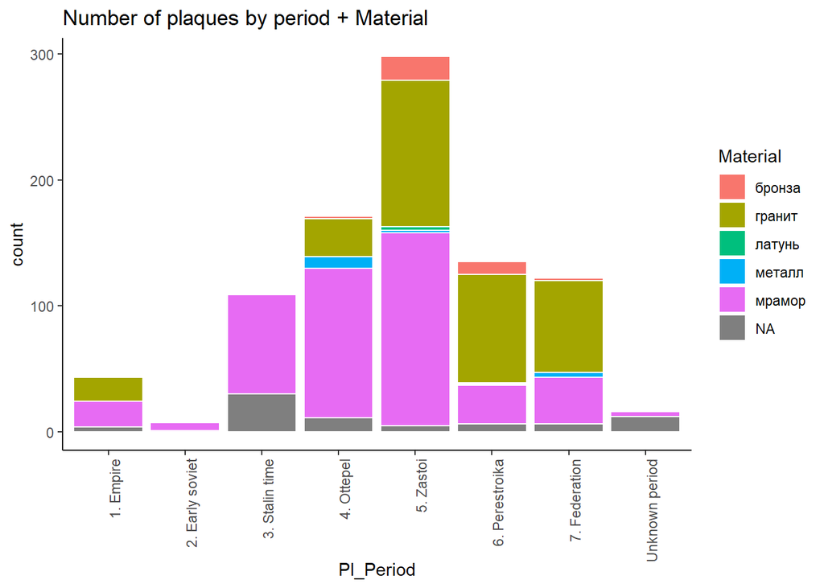

##Lenin stats The most plaqued individual is Lenin, so it makes sense to look at him moreclosely. Patterns can be found regarding Lenins bith and death dates.

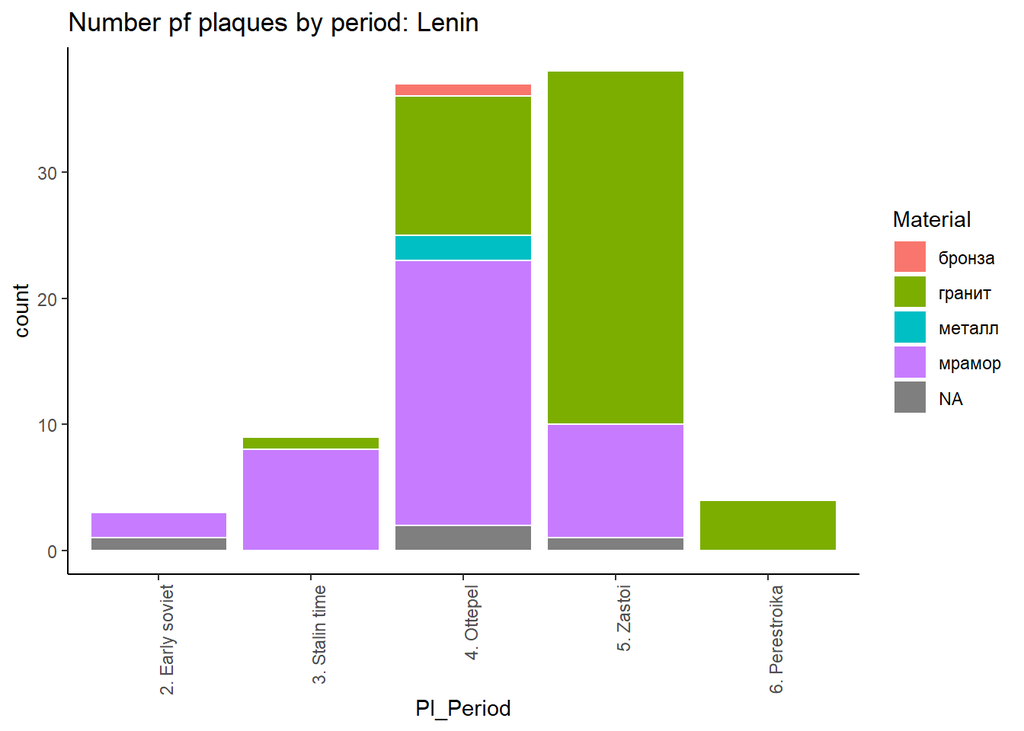

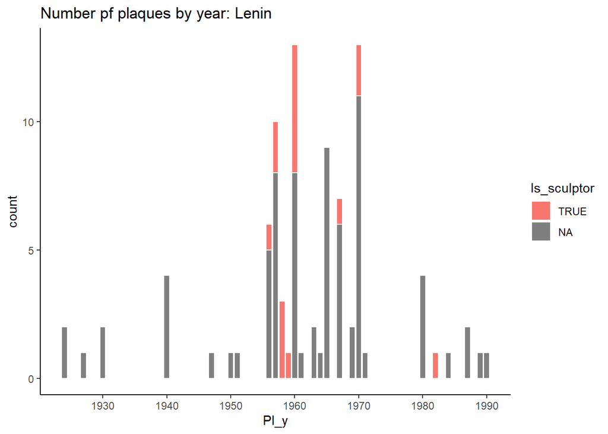

## Is there connectionin general between death date and plaque date in death related plaques?

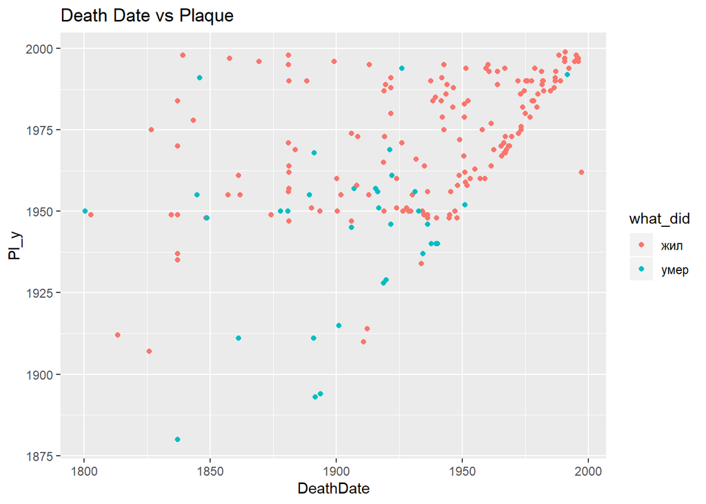

## Let’s look at their locations.

[figure not shown]

This is it for now, but I am planning on continuing the research and unfolding some more interesting facts and patterns and try and build a clustering model.